# Task 2: Classification: Predict which Brand of Products Customers Prefer

#### Note to the reader

> markdown comments noted by the student/author (John Leonard) are highlighted in red. The final section of the document (section 7) contains the informal written report <>

### Your Task:

**FROM:** Danielle Sherman  
**Subject:** Brand Preference Prediction Hello,

Let me begin by thanking you for your investigation into the use of R in our day-to-day data analytics activities. I believe it’s going to be a useful addition, and your investigation was integral in my decision to bring on board as one of our main tools. We will not be replacing RapidMiner completely, since RapidMiner is a very useful tool for visualization and analytics, but we will be using R and R Studio going forward in the next project since we have some deep analytics work to do. Speaking of that…

The sales team engaged a market research firm to conduct a survey of our existing customers. One of the objectives of the survey was to find out which of two brands of computers our customers prefer. This information will help us decide with which manufacturer we should pursue a deeper strategic relationship. Unfortunately, the answer to the brand preference question was not properly captured for all of the respondents.

That is where you come in: I want you to investigate if customer responses to some survey questions (e.g. income, age, etc.) enable us to predict the answer to the brand preference question. If we can do this with confidence, I would like you to make those predictions and provide the sales team with a complete view of what brand our customers prefer.

To do this, I would like you to run and optimize at least two different decision tree classification methods in R - C5.0 and RandomForest - and compare which one works better for this data set.

I have already set up the data for you in the attached CSV files: the file labelled CompleteResponses.csv is the data set you will use to train your model and build your predictive model. It includes ~10,000 fully-answered surveys and the key to the survey can be found in survey_key.csv. The file labelled SurveyIncomplete.csv will be your main test set (the data you will apply your optimized model to predict the brand preference). You’ll be applying your trained and tested model to this data to prepare the model for production.

When you have completed your analysis, please submit a brief report that includes the methods you tried and your results. I would also like to see the results exported from R for each of the classifiers you tried.

Thanks, Danielle

Danielle Sherman Chief Technology Officer Blackwell Electronics www.blackwellelectronics.com

**[survey key](https://s3.amazonaws.com/gbstool/emails/2898/survey%20key.xlsx?AWSAccessKeyId=AKIAJBIZLMJQ2O6DKIAA&Expires=1549184400&Signature=khsHJlHm4C%2Bku4kWqX7Deiu39w4%3D)**  
**[CompleteResponses](https://s3.amazonaws.com/gbstool/emails/2898/CompleteResponses.csv?AWSAccessKeyId=AKIAJBIZLMJQ2O6DKIAA&Expires=1549184400&Signature=GSJfN3AZgi5IV9XM0OhxaKGGtBY%3D)**  
**[SurveyIncomplete](https://s3.amazonaws.com/gbstool/emails/2898/SurveyIncomplete.csv?AWSAccessKeyId=AKIAJBIZLMJQ2O6DKIAA&Expires=1549184400&Signature=X1Qpf7i%2FYupchclG35bEvtwPEz4%3D)**

## Plan of Attack

### Introduction

You have been asked by Danielle Sherman, CTO of Blackwell Electronics, to predict the customers’ brand preferences that are missing from the incomplete surveys by conducting two classification methods in R. Once you have determined which classifier — C5.0 or RandomForest —works better on the provided data set, she would like you to predict the brand preferences for the incomplete survey responses and prepare a report of your findings.

**This task requires you to prepare one deliverable for Danielle Sherman:**

- Customer Brand Preferences Report. A report in a Zip file that includes:
  - A brief summary in Word or Excel of your methods and results that includes:
    - The classifiers you tried.
    - The classifier you selected to make the predictions, including a rationale for selecting the method you did and the level of confidence in the predictions.
    - The predicted answers to the brand preference question for the instances of survey results that are missing that answer.
    - A chart that displays the customer preference for each brand based on the combination of the actual answers and the predicted answers to the brand preference survey question.
    - The results of each classifier you ran exported from R

The steps in the following tabs will walk you through this process.

### 1. Get Started

1. Review the email from Danielle to understand the details of the task.
2. Download the attachments:
   1. Complete Responses: This csv file contains the 10,000 completed survey responses - you’ll use this file to build trained and predictive models using the caret package.
   2. Survey Key: This file also includes a tab that explains the survey questions and the numeric code for each of the possible answers in the survey.
   3. Survey_Incomplete: This is the data set you will use to test your model. It includes 5,000 observations, but no brand preference - this is what you’ll be predicting.

In general, you must be cautious when analyzing externally supplied data

### 2. Learn the Basics of The Caret Package

The caret package (short for Classification And REgression Training) is a set of functions that attempt to streamline the process for creating predictive models. The package contains tools for:

- data splitting
- pre-processing
- feature selection
- model tuning using resampling
- variable importance estimation

In this step you will work through the following exercises to become more familiar with this all-important package for R; you will be using caret throughout the remainder of the program so it is very important that you become very confident with applying it to data analytics problems. To do this you will need to work through a short tutorial on the package and be prepared to discuss your questions and findings in the weekly mentor meetings.

To begin:

1. Work through the “A Short Introduction to the caret Package”" tutorial so you can understand how the training process in caret works. You’ll need the skills from the tutorial to work through the remainder of this task so be sure to allocate enough time for working the examples and working through some of the free datasets from the optional resources in task one to reinforce your learning.

### A Short Introduction to the caret Package

> **Max Kuhn**  
> **max.kuhn@pfizer.com August 6, 2015**  
> The caret package (short for classification and regression training) contains functions to streamline the model training process for complex regression and classification problems. The package utilizes a number of R packages but tries not to load them all at package start-up. The package “suggests” field includes 27 packages. caret loads packages as needed and assumes that they are installed. Install caret using

```r
#install.packages("caret",
#                 repos = "http://cran.r-project.org",
#                 dependencies = c("Depends", "Imports", "Suggests"))
#install.packages("ggplot2")
#install.packages("bindrcpp")
#install.packages('generics')
#install.packages('gower')
```

> The main help pages for the package are at: http://caret.r-forge.r-project.org/ Here, there are extended examples and a large amount of information that previously found in the package vignettes. caret has several functions that attempt to streamline the model building and evaluation process, as well as feature selection and other techniques. One of the primary tools in the package is the train function which can be used to * evaluate, using resampling, the effect of model tuning parameters on performance * choose the “optimal” model across these parameters * estimate model performance from a training set There are options for customizing almost every step of this process (e.g. resampling technique, choosing the optimal parameters etc). To demonstrate this function, the Sonar data from the mlbench package will be used. The Sonar data consist of 208 data points collected on 60 predictors. The goal is to predict the two classes (M for metal cylinder or R for rock). First, we split the data into two groups: a training set and a test set. To do this, the createDataPartition function is used: <>

```r
library(caret)
library(mlbench)
data(Sonar)
set.seed(107)
inTrain <- createDataPartition(y=Sonar$Class, ## the outcome data are needed
                               p=0.75, ## the percentage of data in the training set
                               list = FALSE) #The format of the results)
## The output is a set of integers for the rows of Sonar that belong in the training set
str(inTrain)
```

```
 int [1:157, 1] 1 2 3 6 7 9 10 11 12 13 ...
 - attr(*, "dimnames")=List of 2
  ..$ : NULL
  ..$ : chr "Resample1"
```

> By default, createDataPartition does a stratified random split of the data. To partition the data: <>

```r
training <- Sonar [inTrain]
testing <- Sonar[-inTrain,]
print(paste('NROW(training):',NROW(training)))
```

[output not shown]

```r
print(paste('NROW(testing):',NROW(testing)))
```

```
[1] "NROW(testing): 51"
```

```r
#plsFit <- train(Class ~., data = training,
#                method = "pls",
#                ## Center and scale the predictors for the training set and all future samples
                preProc = c("center","scale"))
```

```
Error: unexpected ')' in "                preProc = c("center","scale"))"
```

**Learn the Basics of The Caret Package… continued**

2. After working through the introduction to the caret package: Develop a working ‘pipeline’ (an example can be seen in the resources) for model training/testing using the caret package so you can easily train/test different models for the capstone. At a minimum you should utilize the following functions with a definitive training and testing set that you will build from the training data that you have already sampled:
- createDataPartition()
- trainControl()
- train()
- predict()
- postResample()
3. You might also find it quite useful to use an alternate tuning grid such as expand.grid, which can be used to specific any of the numerous training parameters that are available with many of the model that are available in the caret package.

TIP: Note: caret uses two grid methods for tuning: Automatic Grid (automated tuning) and Manual Grid (you specify the parameter values). TuneLength can also be added to training with Automatic Grids for models with numeric hyperparameter values (K value in KNN, for example). This method uses caret’s ‘best guess’ for the numeric parameter values and will limit the model runs according to the number of tuneLengths, but does not work on non-numeric values and will increase training time(s), which is not necessarily a bad thing.

TIP: This is a good way of getting start with automated tuning if you are using models that support such. Otherwise caret might spend a great deal of time building many models until the process has been optimized.

TIP: caret can also use a random search for tuning hyperparameters. tuneLength isnt used when using Random Search

There are additional tutorials on the caret package in the optional resources.

#### ML Pipeline

##### Slice, Preprocess, Train-Test Split

```r
#caret model - Automatic Tuning Grid
#http://topepo.github.io/caret/bytag.html
#model training: http://topepo.github.io/caret/training.html
#model measurement: http://topepo.github.io/caret/other.html
#dataframe = WholeYear
#Y Value = SolarRad
#load library and set seed
library(caret)
library(readr)
set.seed(998)
#load the data set
WholeYear<- read_csv("WholeYear.csv");
print(paste("NROW(WholeYear):",NROW(WholeYear)))
```

```
[1] "NROW(WholeYear): 35136"
```

```r
#create a 20% sample of the data
subset_ratio = 0.2
print(paste('subset_ratio',subset_ratio))
```

```
[1] "subset_ratio 0.2"
```

```r
subset_size = round(NROW(WholeYear)*subset_ratio,0)
WholeYear <- WholeYear[sample(1:nrow(WholeYear), subset_size,replace=FALSE),]
print(paste("NROW(WholeYear) Subset:",NROW(WholeYear)))
```

```
[1] "NROW(WholeYear) Subset: 7027"
```

```r
#define a 75-25% train-test split of the dataset
inTraining <- createDataPartition(WholeYear$SolarRad, p = .75, list = FALSE)
training <- WholeYear[inTraining,]
testing <- WholeYear[-inTraining,]
#10 fold cross validation
fitControl <- trainControl(method = "repeatedcv", number = 10, repeats = 1)
```

##### caret model - Automatic Grid - Random Forest

```r
#train Random Forest Regression model with a tuneLenght = 1 (trains with 1 mtry value for RandomForest)
rfFit_autogrid_1<- train(SolarRad~., data = training, method = "rf", trControl=fitControl, tuneLength = 1)
#training results
rfFit_autogrid_1
```

```
Random Forest

5271 samples
   7 predictor

No pre-processing
Resampling: Cross-Validated (10 fold, repeated 1 times)
Summary of sample sizes: 4744, 4743, 4744, 4743, 4745, 4744, ...
Resampling results:

  RMSE      Rsquared   MAE
  84.64967  0.9046372  48.09927

Tuning parameter 'mtry' was held constant at a value of 2
```

```r
#train Random Forest Regression model with a tuneLenght = 2 (trains with 2 mtry values for RandomForest)
rfFit_autogrid_2 <- train(SolarRad~., data = training, method = "rf", trControl=fitControl, tuneLength = 2)
#training results
rfFit_autogrid_2
```

```
Random Forest

5271 samples
   7 predictor

No pre-processing
Resampling: Cross-Validated (10 fold, repeated 1 times)
Summary of sample sizes: 4744, 4743, 4744, 4744, 4743, 4743, ...
Resampling results across tuning parameters:

  mtry  RMSE      Rsquared   MAE
  2     84.31088  0.9053028  47.86665
  7     82.58053  0.9057808  41.58025

RMSE was used to select the optimal model using the smallest value.
The final value used for the model was mtry = 7.
```

##### caret model - Manual Grid - Random Forest

```r
#dataframe for manual tuning of mtry
rfGrid <- expand.grid(mtry=c(1,2,3))
#train Random Forest Regression model
#note the system time wrapper. system.time()
#this is used to measure process execution time
system.time(rfFit_manualgrid_1 <- train(SolarRad~., data = training, method = "rf", trControl=fitControl, tuneGrid=rfGrid))
```

```
   user  system elapsed
227.311   3.325 231.253
```

```r
#training results
rfFit_manualgrid_1
```

```
Random Forest

5271 samples
   7 predictor

No pre-processing
Resampling: Cross-Validated (10 fold, repeated 1 times)
Summary of sample sizes: 4745, 4744, 4743, 4743, 4745, 4743, ...
Resampling results across tuning parameters:

  mtry  RMSE      Rsquared   MAE
  1     97.61393  0.8808622  61.77288
  2     84.45396  0.9043399  47.99523
  3     82.35951  0.9070724  43.96085

RMSE was used to select the optimal model using the smallest value.
The final value used for the model was mtry = 3.
```

##### caret model - Random Tuning Search - Random Forest

```r
#10 fold cross validation
rfitControl <- trainControl(method = "repeatedcv", number = 10, repeats = 1, search = 'random')
#train Random Forest Regression model
rfFit_randomsearch_1 <- train(SolarRad~., data = training, method = "rf", trControl=rfitControl)
#training results
rfFit_randomsearch_1
```

```
Random Forest

5271 samples
   7 predictor

No pre-processing
Resampling: Cross-Validated (10 fold, repeated 1 times)
Summary of sample sizes: 4744, 4744, 4742, 4744, 4745, 4744, ...
Resampling results across tuning parameters:

  mtry  RMSE      Rsquared   MAE
  3     82.49017  0.9068798  44.03264
  7     83.44110  0.9036185  41.92552

RMSE was used to select the optimal model using the smallest value.
The final value used for the model was mtry = 3.
```

##### caret model - Automatic Grid - Linear Model

```r
#10 fold cross validation
fitControl <- trainControl(method = "repeatedcv", number = 10, repeats = 1)
#train Linear Regression model
LMFit_autogrid_1 <- train(SolarRad~., data = training, method = "lm", trControl=fitControl)
#check the results
LMFit_autogrid_1
```

```
Linear Regression

5271 samples
   7 predictor

No pre-processing
Resampling: Cross-Validated (10 fold, repeated 1 times)
Summary of sample sizes: 4743, 4744, 4744, 4745, 4744, 4742, ...
Resampling results:

  RMSE      Rsquared   MAE
  190.4205  0.4993306  150.6668

Tuning parameter 'intercept' was held constant at a value of TRUE
```

##### Prediction Assessment in caret

caret has many built-in functions for checking how well our models make predictions; here are a few you can use:

- defaultSummary(data, lev = NULL, model = NULL)
- postResample(pred, obs)
- twoClassSummary(data, lev = NULL, model = NULL)
- mnLogLoss(data, lev = NULL, model = NULL)
- multiClassSummary(data, lev = NULL, model = NULL)
- prSummary(data, lev = NULL, model = NULL)

```
[[1]]
Random Forest

5271 samples
   7 predictor

No pre-processing
Resampling: Cross-Validated (10 fold, repeated 1 times)
Summary of sample sizes: 4744, 4743, 4744, 4743, 4745, 4744, ...
Resampling results:

  RMSE      Rsquared   MAE
  84.64967  0.9046372  48.09927

Tuning parameter 'mtry' was held constant at a value of 2

[[1]]
Random Forest

5271 samples
   7 predictor

No pre-processing
Resampling: Cross-Validated (10 fold, repeated 1 times)
Summary of sample sizes: 4744, 4743, 4744, 4744, 4743, 4743, ...
Resampling results across tuning parameters:

  mtry  RMSE      Rsquared   MAE
  2     84.31088  0.9053028  47.86665
  7     82.58053  0.9057808  41.58025

RMSE was used to select the optimal model using the smallest value.
The final value used for the model was mtry = 7.
```

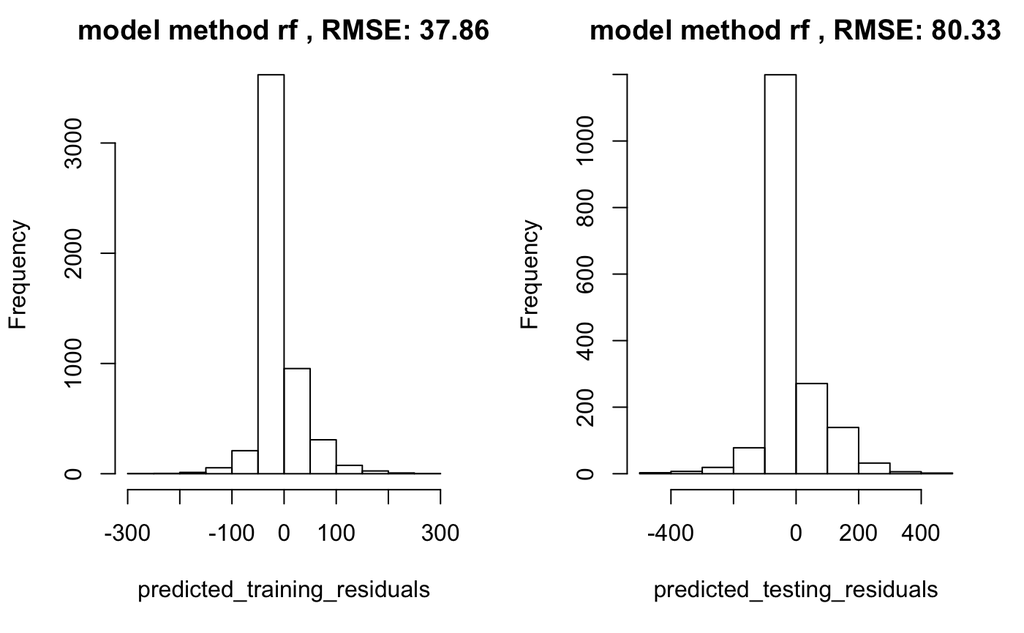

```
[[1]]
Random Forest

5271 samples
   7 predictor

No pre-processing
Resampling: Cross-Validated (10 fold, repeated 1 times)
Summary of sample sizes: 4745, 4744, 4743, 4743, 4745, 4743, ...
Resampling results across tuning parameters:

  mtry  RMSE      Rsquared   MAE
  1     97.61393  0.8808622  61.77288
  2     84.45396  0.9043399  47.99523
  3     82.35951  0.9070724  43.96085

RMSE was used to select the optimal model using the smallest value.
The final value used for the model was mtry = 3.
```

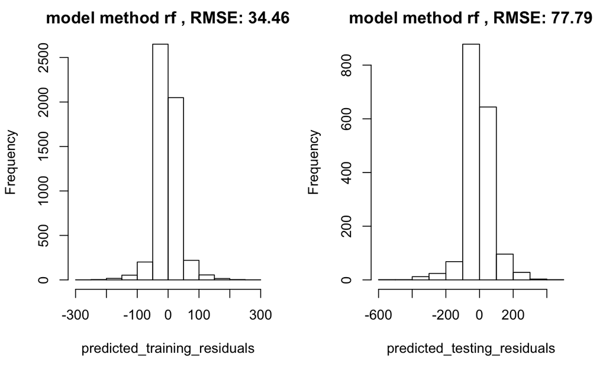

```
[[1]]
Random Forest

5271 samples
   7 predictor

No pre-processing
Resampling: Cross-Validated (10 fold, repeated 1 times)
Summary of sample sizes: 4744, 4744, 4742, 4744, 4745, 4744, ...
Resampling results across tuning parameters:

  mtry  RMSE      Rsquared   MAE
  3     82.49017  0.9068798  44.03264
  7     83.44110  0.9036185  41.92552

RMSE was used to select the optimal model using the smallest value.
The final value used for the model was mtry = 3.
```

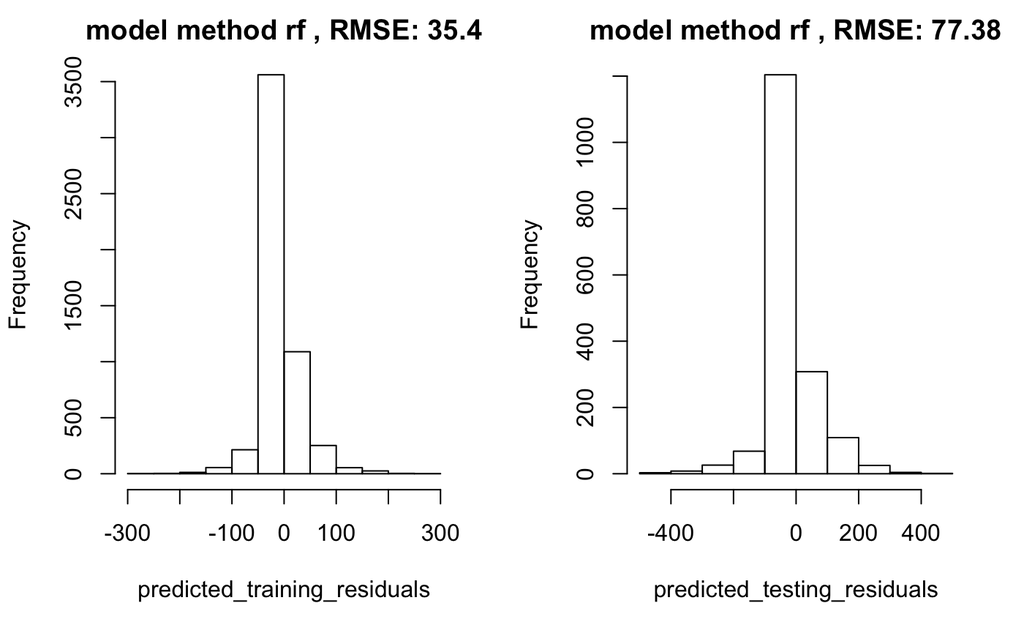

```
[[1]]
Linear Regression

5271 samples
   7 predictor

No pre-processing
Resampling: Cross-Validated (10 fold, repeated 1 times)
Summary of sample sizes: 4743, 4744, 4744, 4745, 4744, 4742, ...
Resampling results:

  RMSE      Rsquared   MAE
  190.4205  0.4993306  150.6668

Tuning parameter 'intercept' was held constant at a value of TRUE
```

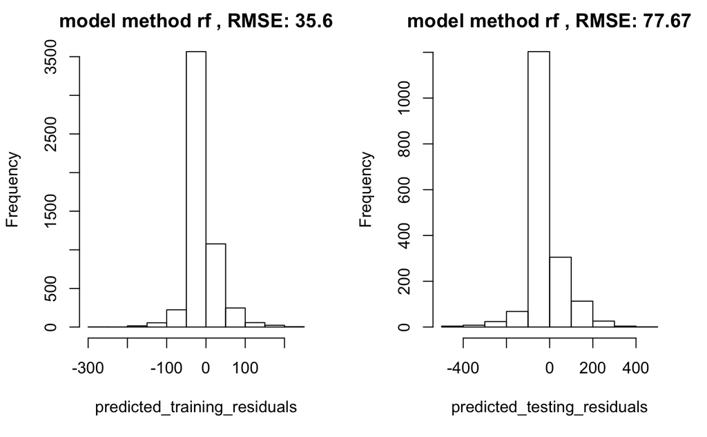

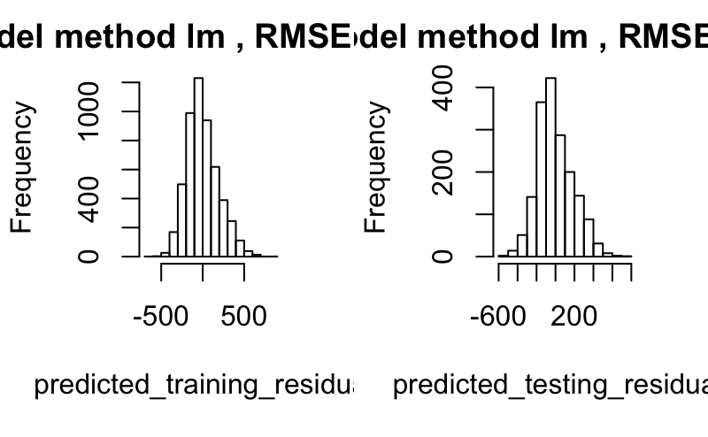

```r
# Prediction for the previously trained models
model_list = list(rfFit_autogrid_1, rfFit_autogrid_2, rfFit_manualgrid_1, rfFit_randomsearch_1, LMFit_autogrid_1)
y_training <- training$SolarRad
y_testing <- testing$SolarRad
for(i in 1:length(model_list )){
  model_ID <- model_list[i]
  print(model_ID)

  predicted_training <- predict(model_ID, newdata = training)[[1]]
  predicted_training_residuals <- y_training - predicted_training
  RMSE_training = round(RMSE(pred = predicted_training, obs = y_training),2)
  predicted_testing <- predict(model_ID, newdata = testing)[[1]]
  predicted_testing_residuals <- y_testing - predicted_testing
  RMSE_testing = round(RMSE(pred = predicted_testing, obs = y_testing),2)

  subplot_rows = 1
  subplot_cols = 2
  par(mfrow=c(subplot_rows,subplot_cols))

  hist(predicted_training_residuals, xlab = 'predicted_training_residuals',main = paste("model method",model_ID[[1]]["method"], ", RMSE:" ,   RMSE_training))
  hist(predicted_testing_residuals, xlab = 'predicted_testing_residuals', main = paste("model method",model_ID[[1]]["method"], ', RMSE:',   RMSE_testing))



}
```

### 3. Train the Models

1. Import and familiarize yourself with the training set. The file CompleteResponses is an CSV file that includes answers to all the questions in the market research survey, including which brand of computer products the customer prefers. You will be using this data set to train and test the classifier to make predictions. You will notice that there is a mix of numeric and nominal values; some might need to be converted to factors. Consult the Survey Key to gain an understanding of what the survey response values mean. The coding key’s primary function is to help you understand the coding of the survey – you only need the coding key to prepare the labels in your final preferences graph.

```r
#load library and set seed
library(caret)
library(readr)
set.seed(998)
#load the data set
df <- read_csv("CompleteResponses.csv");
head(df)
```

| salary | age | elevel | car | zipcode | credit | brand |
| --- | --- | --- | --- | --- | --- | --- |
| 119806.54 | 45 | 0 | 14 | 4 | 442037.71 | 0 |
| 106880.48 | 63 | 1 | 11 | 6 | 45007.18 | 1 |
| 78020.75 | 23 | 0 | 15 | 2 | 48795.32 | 0 |
| 63689.94 | 51 | 3 | 6 | 5 | 40888.88 | 1 |
| 50873.62 | 20 | 3 | 14 | 4 | 352951.50 | 0 |
| 130812.74 | 56 | 3 | 14 | 3 | 135943.02 | 1 |

```r
print(paste("NROW(df):",NROW(df)))
```

```
[1] "NROW(df): 9898"
```

```r
# Update Data Types
df$"elevel" <- as.factor(df$"elevel")
df$"car" <- as.factor(df$"car")
df$"zipcode" <- as.factor(df$zipcode)
df$brand<-as.factor(df$brand)
Get_to_know_data <- function(df){
  print(paste("GET TO KNOW: ",deparse(substitute(df))))

  print('fetching summary...')
  print(summary(df) )#Prints the min, max, mean, median, and quartiles of each attribute.

  print('fetching data structure...')
  print(str(df) )#Displays the structure of your data set.

}
Get_to_know_data(df)
```

```
[1] "GET TO KNOW:  df"
[1] "fetching summary..."
     salary            age        elevel        car          zipcode         credit
 Min.   : 20000   Min.   :20.00   0:2052   15     : 542   6      :1155   Min.   :     0
 1st Qu.: 52082   1st Qu.:35.00   1:1948   18     : 524   8      :1135   1st Qu.:120807
 Median : 84950   Median :50.00   2:1983   8      : 511   2      :1112   Median :250607
 Mean   : 84871   Mean   :49.78   3:1947   2      : 509   5      :1108   Mean   :249176
 3rd Qu.:117162   3rd Qu.:65.00   4:1968   17     : 508   4      :1087   3rd Qu.:374640
 Max.   :150000   Max.   :80.00            5      : 505   0      :1085   Max.   :500000
                                           (Other):6799   (Other):3216
 brand
 0:3744
 1:6154





[1] "fetching data structure..."
Classes ‘spec_tbl_df’, ‘tbl_df’, ‘tbl’ and 'data.frame':    9898 obs. of  7 variables:
 $ salary : num  119807 106880 78021 63690 50874 ...
 $ age    : num  45 63 23 51 20 56 24 62 29 41 ...
 $ elevel : Factor w/ 5 levels "0","1","2","3",..: 1 2 1 4 4 4 5 4 5 2 ...
 $ car    : Factor w/ 20 levels "1","2","3","4",..: 14 11 15 6 14 14 8 3 17 5 ...
 $ zipcode: Factor w/ 9 levels "0","1","2","3",..: 5 7 3 6 5 4 6 1 1 5 ...
 $ credit : num  442038 45007 48795 40889 352951 ...
 $ brand  : Factor w/ 2 levels "0","1": 1 2 1 2 1 2 2 2 1 2 ...
 - attr(*, "spec")=
  .. cols(
  ..   salary = col_double(),
  ..   age = col_double(),
  ..   elevel = col_double(),
  ..   car = col_double(),
  ..   zipcode = col_double(),
  ..   credit = col_double(),
  ..   brand = col_double()
  .. )
NULL
```

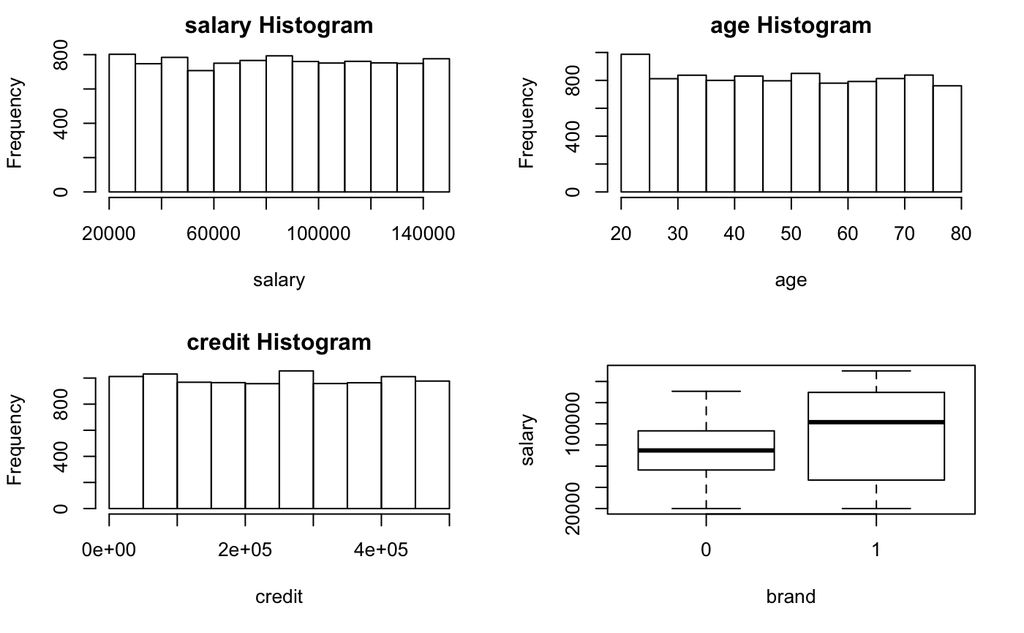

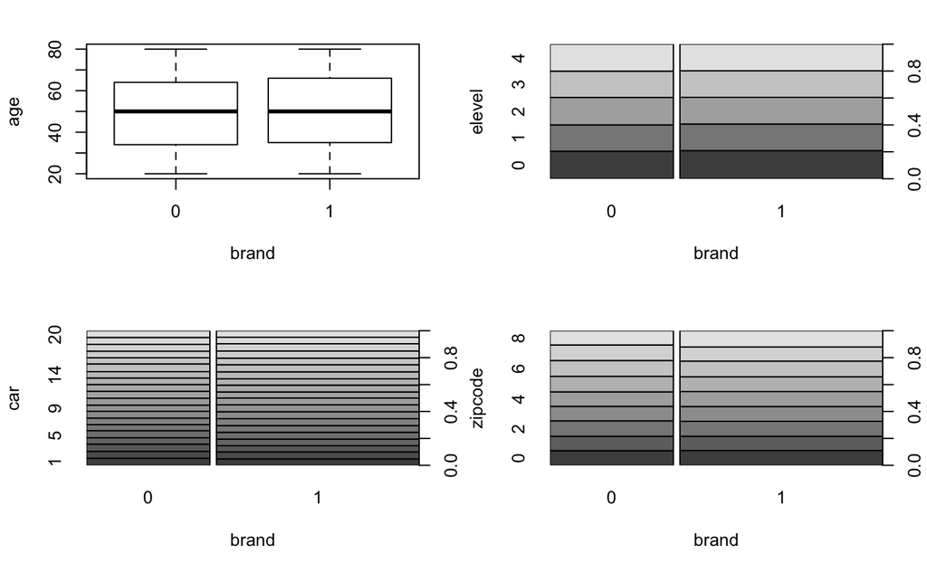

[figure not shown]

```r
plot_summary_of_data<-function(DatasetName,x_index=1){

  column_names = names(DatasetName)

  subplot_cols = 2
  subplot_rows = 2
  par(mfrow=c(subplot_rows,subplot_cols))

  x <- unlist(DatasetName[,x_index])
  x_header = column_names[x_index]

  for(i in 1:length(column_names)){
    y <- unlist(DatasetName[,i])
    y_header = column_names[i]
    try(hist(y, main = paste(y_header, "Histogram"), xlab = y_header ),silent=TRUE)#Histogram Plot
  }

  for(i in 1:length(column_names)){

    if(i != x_index) {
    y <- unlist(DatasetName[,i])
    y_header = column_names[i]

    try(plot(x,y, xlab = x_header, ylab = y_header),silent=TRUE)  #Scatter (Box) Plot
    }
  }

  #Normal Quantile Plot- is a way to see if your data is normally distributed.
  for(i in 1:length(column_names)){

    y <- unlist(DatasetName[,i])
    y_header = column_names[i]

 try(qqnorm(y,main = paste(y_header, " Normal Q-Q Plot")),silent=TRUE) ##Normal Quantile Plot
  }
}
plot_summary_of_data(df,x_index=7)
```

- Perform any necessary pre-processing.

```r
# calculate the pre-process parameters from the dataset
preprocessParams <- preProcess(df, method=c("scale"))
# summarize transform parameters
print(preprocessParams)
```

```
Created from 9898 samples and 7 variables

Pre-processing:
  - ignored (4)
  - scaled (3)
```

```r
# transform the dataset using the parameters
df_preprocesssed<- predict(preprocessParams, df)
# summarize the transformed dataset
Get_to_know_data(df_preprocesssed)
```

```
[1] "GET TO KNOW:  df_preprocesssed"
[1] "fetching summary..."
     salary            age        elevel        car          zipcode         credit
 Min.   :0.5303   Min.   :1.137   0:2052   15     : 542   6      :1155   Min.   :0.0000
 1st Qu.:1.3810   1st Qu.:1.989   1:1948   18     : 524   8      :1135   1st Qu.:0.8319
 Median :2.2526   Median :2.841   2:1983   8      : 511   2      :1112   Median :1.7258
 Mean   :2.2505   Mean   :2.829   3:1947   2      : 509   5      :1108   Mean   :1.7160
 3rd Qu.:3.1067   3rd Qu.:3.694   4:1968   17     : 508   4      :1087   3rd Qu.:2.5800
 Max.   :3.9775   Max.   :4.546            5      : 505   0      :1085   Max.   :3.4433
                                           (Other):6799   (Other):3216
 brand
 0:3744
 1:6154





[1] "fetching data structure..."
Classes ‘spec_tbl_df’, ‘tbl_df’, ‘tbl’ and 'data.frame':    9898 obs. of  7 variables:
 $ salary : num  3.18 2.83 2.07 1.69 1.35 ...
 $ age    : num  2.56 3.58 1.31 2.9 1.14 ...
 $ elevel : Factor w/ 5 levels "0","1","2","3",..: 1 2 1 4 4 4 5 4 5 2 ...
 $ car    : Factor w/ 20 levels "1","2","3","4",..: 14 11 15 6 14 14 8 3 17 5 ...
 $ zipcode: Factor w/ 9 levels "0","1","2","3",..: 5 7 3 6 5 4 6 1 1 5 ...
 $ credit : num  3.044 0.31 0.336 0.282 2.431 ...
 $ brand  : Factor w/ 2 levels "0","1": 1 2 1 2 1 2 2 2 1 2 ...
 - attr(*, "spec")=
  .. cols(
  ..   salary = col_double(),
  ..   age = col_double(),
  ..   elevel = col_double(),
  ..   car = col_double(),
  ..   zipcode = col_double(),
  ..   credit = col_double(),
  ..   brand = col_double()
  .. )
NULL
```

- Perform any necessary Feature Engineering/Selection

If most of the data was continuous I would plot a correlation matrix to see if we should drop highly correlated features, but since most of it is categorical/factor in type, we won’t run this process here. Regardless of that though, let’s check for any NA…

```r
anyNA(df_preprocesssed)
```

```
[1] FALSE
```

- Using createDataPartition create training and test sets. These will be created from the CompleteResponses.csv file. The training data should represent 75% of the total data and the remaining 25% will be used for testing. After optimizing your model you’ll later use it to make predictions on the incomplete surveys.

```r
#setup seed for reproducability
set.seed(998)
#define a 75-25% train-test split of the dataset
y <- df_preprocesssed$brand
inTraining <- createDataPartition(y, p = .75, list = FALSE)
training <- df_preprocesssed[inTraining,]
testing <- df_preprocesssed[-inTraining,]
#check dimensions of train & test set
dim(training); dim(testing);
```

```
[1] 7424    7
[1] 2474    7
```

- Build a model using a decision tree, C5.0, on the training set with 10-fold cross validation and an Automatic Tuning Grid with a tuneLength of 2. In an earlier task, you used another decision trees, Gradient Boosted Trees, to predict a specific numeric value (the sales volume of a new product); in this task you will use C5.0 to predict nominal data (a customer’s computer brand preference). The main difference is that, in numeric prediction, you are inferring a real number (such as how many products may be sold in a period of time) while, in nominal (or categorical) prediction, you are selecting what class a given observation belongs to.

```r
model
```

```
C5.0

7424 samples
   6 predictor
   2 classes: '0', '1'

No pre-processing
Resampling: Cross-Validated (10 fold, repeated 1 times)
Summary of sample sizes: 6681, 6682, 6682, 6682, 6682, 6681, ...
Resampling results across tuning parameters:

  model  winnow  trials  Accuracy   Kappa
  rules  FALSE    1      0.8178888  0.6368363
  rules  FALSE   10      0.9187776  0.8268130
  rules   TRUE    1      0.8293296  0.6587103
  rules   TRUE   10      0.9229504  0.8354124
  tree   FALSE    1      0.8178888  0.6368363
  tree   FALSE   10      0.9232203  0.8368493
  tree    TRUE    1      0.8290604  0.6581053
  tree    TRUE   10      0.9181014  0.8257198

Accuracy was used to select the optimal model using the largest value.
The final values used for the model were trials = 10, model = tree and winnow = FALSE.
```

1. Assess the performance of the trained model and record the Accuracy and Kappa scores for each parameter value the model used during training.

```r
model
```

```
C5.0

7424 samples
   6 predictor
   2 classes: '0', '1'

No pre-processing
Resampling: Cross-Validated (10 fold, repeated 1 times)
Summary of sample sizes: 6681, 6682, 6682, 6682, 6682, 6681, ...
Resampling results across tuning parameters:

  model  winnow  trials  Accuracy   Kappa
  rules  FALSE    1      0.8178888  0.6368363
  rules  FALSE   10      0.9187776  0.8268130
  rules   TRUE    1      0.8293296  0.6587103
  rules   TRUE   10      0.9229504  0.8354124
  tree   FALSE    1      0.8178888  0.6368363
  tree   FALSE   10      0.9232203  0.8368493
  tree    TRUE    1      0.8290604  0.6581053
  tree    TRUE   10      0.9181014  0.8257198

Accuracy was used to select the optimal model using the largest value.
The final values used for the model were trials = 10, model = tree and winnow = FALSE.
```

```r
#save unique model ID
model_decision_tree_C5 = model
```

2. Use VarImp() to ascertain how the model prioritized each feature in the training (more on this in the resources)

```r
# Analyze Variable Importance
varImp(model)
```

```
C5.0 variable importance

  only 20 most important variables shown (out of 34)
```

|  | Overall |
| --- | --- |
| salary | 100.0 |
| age | 85.1 |
| zipcode4 | 0.0 |
| car12 | 0.0 |
| car9 | 0.0 |
| car7 | 0.0 |
| car5 | 0.0 |
| zipcode3 | 0.0 |
| car18 | 0.0 |
| car6 | 0.0 |

[output cut: 10 more lines]

TIP: Remember that the data mining algorithms make the prediction in both types of tasks based on the similarities and differences between the attributes (columns) of observations (rows). You will be classifying “brand” in this task.

6. Use Random Forest with 10-fold cross validation and manually tune 5 different mtry values. Using the same caret pipeline you developed for the previous step and the same training data, build a trained model using the Random Forest classifier in the caret package.

```r
test=test
```

[output not shown]

```
Error: object 'test' not found
```

After building the trained model 1. Assess the performance of the trained model and record the Accuracy and Kappa scores for each number of features the model used during training.

```r
#training results
rfFit_manualgrid_1
```

```
Random Forest

7424 samples
   6 predictor
   2 classes: '0', '1'

No pre-processing
Resampling: Cross-Validated (10 fold, repeated 1 times)
Summary of sample sizes: 6681, 6682, 6681, 6682, 6682, 6681, ...
Resampling results across tuning parameters:

  mtry  Accuracy   Kappa
  1     0.6217673  0.0000000000
  2     0.6219020  0.0004418206
  3     0.7267010  0.3390088145
  4     0.8537144  0.6805815658
  5     0.8923742  0.7709911267

Accuracy was used to select the optimal model using the largest value.
The final value used for the model was mtry = 5.
```

2. Use VarImp() to ascertain how the model prioritized each feature in the training (more on this in the resources)

```r
# Analyze Variable Importance
varImp(rfFit_manualgrid_1)
```

```
rf variable importance

  only 20 most important variables shown (out of 34)
```

|  | Overall |
| --- | --- |
| salary | 100.0000000 |
| age | 40.7899450 |
| credit | 19.5454770 |
| elevel3 | 0.8989291 |
| elevel2 | 0.8151075 |
| elevel1 | 0.8132614 |
| elevel4 | 0.7608397 |
| zipcode4 | 0.4374877 |
| zipcode5 | 0.4051055 |
| zipcode7 | 0.3951130 |

[output cut: 10 more lines]